# sealey-briana-ADA-homework-3

Briana Sealey

4/27/2020

```r
#load packages
library(ggplot2)
library(ggthemes)
library(readr)
library(dplyr)
library(tidyverse)
library(gridExtra)
library(broom)
library(infer)
library(boot)
```

```r
#loading data
f <- "https://raw.githubusercontent.com/difiore/ADA-datasets/master/KamilarAndCooperData.csv"
d <- read_csv(f, col_names = TRUE)

head(d, 6)
```

```
## # A tibble: 6 x 44
##   Scientific_Name Family Genus Species Brain_Size_Spec… Brain_Size_Fema…
##   <chr>           <chr>  <chr> <chr>              <dbl>            <dbl>
## 1 Allenopithecus… Cerco… Alle… nigrov…             58.0             53.7
## 2 Allocebus_tric… Cerco… Allo… tricho…             NA               NA
## 3 Alouatta_belze… Ateli… Alou… belzeb…             52.8             51.2
## 4 Alouatta_caraya Ateli… Alou… caraya              52.6             47.8
## 5 Alouatta_guari… Ateli… Alou… guariba             51.7             49.1
## 6 Alouatta_palli… Ateli… Alou… pallia…             49.9             48.0
## # … with 38 more variables: Brain_size_Ref <chr>, Body_mass_male_mean <dbl>,
## #   Body_mass_female_mean <dbl>, Mass_Dimorphism <dbl>, Mass_Ref <chr>,
## #   MeanGroupSize <dbl>, AdultMales <dbl>, AdultFemale <dbl>,
## #   AdultSexRatio <dbl>, Social_Organization_Ref <chr>,
## #   InterbirthInterval_d <dbl>, Gestation <dbl>, WeaningAge_d <dbl>,
## #   MaxLongevity_m <dbl>, LitterSz <dbl>, Life_History_Ref <chr>,
## #   GR_MidRangeLat_dd <dbl>, Precip_Mean_mm <dbl>, Temp_Mean_degC <dbl>,
## #   AET_Mean_mm <dbl>, PET_Mean_mm <dbl>, Climate_Ref <chr>,
## #   HomeRange_km2 <dbl>, HomeRangeRef <chr>, DayLength_km <dbl>,
## #   DayLengthRef <chr>, Territoriality <dbl>, Fruit <dbl>, Leaves <chr>,
## #   Fauna <chr>, DietRef1 <chr>, Canine_Dimorphism <dbl>,
## #   Canine_Dimorphism_Ref <chr>, Feed <dbl>, Move <dbl>, Rest <dbl>,
## #   Social <dbl>, Activity_Budget_Ref <chr>
```

```r
colnames(d)
```

```
##  [1] "Scientific_Name"         "Family"
##  [3] "Genus"                   "Species"
##  [5] "Brain_Size_Species_Mean" "Brain_Size_Female_Mean"
##  [7] "Brain_size_Ref"          "Body_mass_male_mean"
##  [9] "Body_mass_female_mean"   "Mass_Dimorphism"
## [11] "Mass_Ref"                "MeanGroupSize"
## [13] "AdultMales"              "AdultFemale"
## [15] "AdultSexRatio"           "Social_Organization_Ref"
## [17] "InterbirthInterval_d"    "Gestation"
## [19] "WeaningAge_d"            "MaxLongevity_m"
## [21] "LitterSz"                "Life_History_Ref"
## [23] "GR_MidRangeLat_dd"       "Precip_Mean_mm"
## [25] "Temp_Mean_degC"          "AET_Mean_mm"
## [27] "PET_Mean_mm"             "Climate_Ref"
## [29] "HomeRange_km2"           "HomeRangeRef"
## [31] "DayLength_km"            "DayLengthRef"
## [33] "Territoriality"          "Fruit"
## [35] "Leaves"                  "Fauna"
## [37] "DietRef1"                "Canine_Dimorphism"
## [39] "Canine_Dimorphism_Ref"   "Feed"
## [41] "Move"                    "Rest"
## [43] "Social"                  "Activity_Budget_Ref"
```

```r
#Labeling variables
longevity <- d$MaxLongevity_m
brain_size <- d$Brain_Size_Species_Mean
log_longevity <- log(d$MaxLongevity_m)
log_brain_size <- log(d$Brain_Size_Species_Mean)
```

### CHALLENGE 1

#### C1, PART 1

```r
#Creating linear regression
(l1 <- lm(longevity~brain_size))
```

```
##
## Call:
## lm(formula = longevity ~ brain_size)
##
## Coefficients:
## (Intercept)   brain_size
##     248.952        1.218
```

```r
(l2 <- lm(log_longevity~log_brain_size))
```

```
##
## Call:
## lm(formula = log_longevity ~ log_brain_size)
##
## Coefficients:
##    (Intercept)  log_brain_size
##         4.8790          0.2341
```

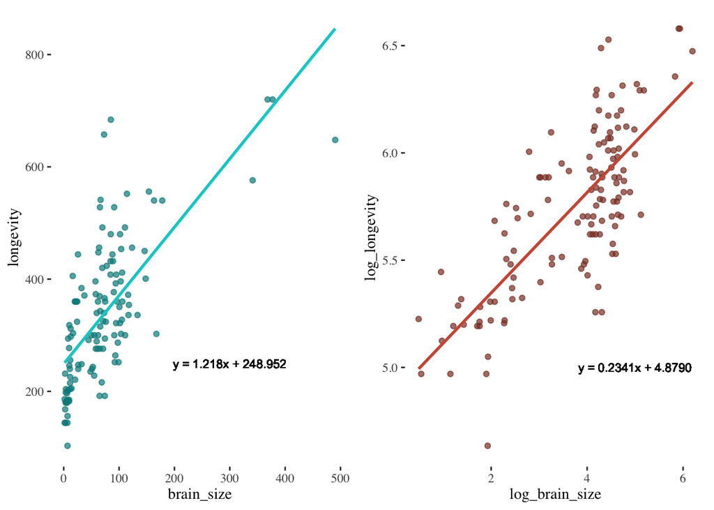

```r
#Sets theme of ggplot graphs
theme_set(theme_tufte())

#Untransformed
p1 <- ggplot(data = d, aes(x = brain_size, y = longevity)) +
  geom_point(color = "cyan4", alpha = 0.70) +
  geom_smooth(method = lm, color = 'cyan3', se = FALSE) +
  geom_text(x = 300, y = 250, label="y = 1.218x + 248.952", size = 3)

#Log transformed
p2 <- ggplot(data = d, aes(x = log_brain_size, y = log_longevity)) +
  geom_point(color = "coral4", alpha = 0.70) +
  geom_smooth(method = lm, color = 'coral3', se = FALSE) +
  geom_text(x = 5, y = 5, label="y = 0.2341x + 4.8790", size = 3)

grid.arrange(p1, p2, ncol = 2, nrow = 1)
```

#### C1, PART 2

```r
#Retrieving linear regression information
summary(l1)
```

```
##
## Call:
## lm(formula = longevity ~ brain_size)
##
## Residuals:
##     Min      1Q  Median      3Q     Max
## -198.27  -61.92  -17.78   56.16  331.36
##
## Coefficients:
##             Estimate Std. Error t value Pr(>|t|)
## (Intercept) 248.9523    11.1111   22.41   <2e-16 ***
## brain_size    1.2180     0.1101   11.06   <2e-16 ***
## ---
## Signif. codes:  0 '***' 0.001 '**' 0.01 '*' 0.05 '.' 0.1 ' ' 1
##
## Residual standard error: 90.91 on 126 degrees of freedom
##   (85 observations deleted due to missingness)
## Multiple R-squared:  0.4928, Adjusted R-squared:  0.4887
## F-statistic: 122.4 on 1 and 126 DF,  p-value: < 2.2e-16
```

```r
summary(l2)
```

```
##
## Call:
## lm(formula = log_longevity ~ log_brain_size)
##
## Residuals:
##     Min      1Q  Median      3Q     Max
## -0.6955 -0.1750 -0.0097  0.1788  0.6084
##
## Coefficients:
##                Estimate Std. Error t value Pr(>|t|)
## (Intercept)     4.87895    0.06907   70.63   <2e-16 ***
## log_brain_size  0.23415    0.01781   13.15   <2e-16 ***
## ---
## Signif. codes:  0 '***' 0.001 '**' 0.01 '*' 0.05 '.' 0.1 ' ' 1
##
## Residual standard error: 0.2485 on 126 degrees of freedom
##   (85 observations deleted due to missingness)
## Multiple R-squared:  0.5784, Adjusted R-squared:  0.5751
## F-statistic: 172.9 on 1 and 126 DF,  p-value: < 2.2e-16
```

```r
#inverse log of beta coefficient for L2
exp(0.23415)
```

```
## [1] 1.263834
```

For a 1 unit increase in brain size, there is a 1.2180 unit increase in longevity. Because $\beta_{1}$ $\neq$ 0, we can reject $H_0$ (null hypothesis).

For a difference of 1 natural log unit in brain size (2.71828…), there is a 1.263834 fold increase in longevity. Because $\beta_{1}$ $\neq$ 0, we can reject $H_0$ (null hypothesis).

```r
#Calculating confidence intervals
confint(l1, level = 0.9)
```

```
##                    5 %      95 %
## (Intercept) 230.540738 267.36379
## brain_size    1.035571   1.40041
```

```r
confint(l2, level = 0.9)
```

```
##                      5 %      95 %
## (Intercept)    4.7644934 4.9934084
## log_brain_size 0.2046396 0.2636595
```

#### C1, PART 3

[figure not shown]

```r
#Calculating confidence intervals of untransformed
ci1 <- predict(l1, newdata = data.frame(brainsize = brain_size), interval = "confidence", level = 0.95)
ci1 <- data.frame(ci1)
ci1 <- cbind(brain_size, ci1)
names(ci1) <- c("brainsize", "c.fit1", "c.lwr1", "c.upr1")

#Calculating prediction lines of untransformed
pred1 <- predict(l1, newdata = data.frame(brainsize = brain_size), interval = "prediction", level = 0.95)
pred1 <- data.frame(pred1)
pred1 <- cbind(brain_size, pred1)
names(pred1) <- c("brainsize", "pred.fit1", "pred.lwr1", "pred.upr1")

#Creating plot for untransformed
p1 <- ggplot(data = d, aes(x = brain_size, y = longevity)) +
  geom_point(alpha = 0.70) +
  geom_smooth(method = lm, color = 'black', se = FALSE) +
  geom_line(data = ci1, aes(x = brain_size, y = c.lwr1, color = "cyan3")) +
  geom_line(data = ci1, aes(x = brain_size, y = c.upr1, color = "cyan3")) +
  geom_line(data = pred1, aes(x = brain_size, y = pred.lwr1, color = "red")) +
  geom_line(data = pred1, aes(x = brain_size, y = pred.upr1, color = "red")) +
  scale_colour_hue(name = "Lines", labels = c("Confidence", "Prediction")) +
  geom_text(x = 300, y = 100, label = "y = 1.218x + 248.952", size = 3)

#Confidence for log-transformed
ci2 <- predict(l2, newdata = data.frame(log.brainsize = log_brain_size), interval = "confidence", level = 0.95)
ci2 <- data.frame(ci2)
ci2 <- cbind(log_brain_size, ci2)
names(ci2) <- c("log.brainsize", "c.fit2", "c.lwr2", "c.upr2")

#Prediction lines for log-transformed
pred2 <- predict(l2, newdata = data.frame(log.brainsize = log_brain_size), interval = "prediction", level = 0.95)
pred2 <- data.frame(pred2)
pred2 <- cbind(log_brain_size, pred2)
names(pred2) <- c("log.brainsize", "pred.fit2", "pred.lwr2", "pred.upr2")

#Plot for log-transformed
p2 <- ggplot(data = d, aes(x = log_brain_size, y = log_longevity)) +
  geom_point(alpha = 0.70) +
  geom_smooth(method = lm, color = 'black', se = FALSE) +
  geom_line(data = ci2, aes(x = log_brain_size, y = c.lwr2, color = "cyan3")) +
  geom_line(data = ci2, aes(x = log_brain_size, y = c.upr2, color = "cyan3")) +
  geom_line(data = pred2, aes(x = log_brain_size, y = pred.lwr2, color = "red")) +
  geom_line(data = pred2, aes(x = log_brain_size, y = pred.upr2, color = "red")) +
  scale_colour_hue(name = "Lines", labels = c("Confidence", "Prediction")) +
  geom_text(x = 5, y = 4.5, label="y = 0.2341x + 4.8790", size = 3)

grid.arrange(p1, p2, ncol = 2, nrow = 1)
```

#### C1, PART 4

```r
#point estimate for untransformed
pred.single1 <- predict(l1, newdata = data.frame(brain_size = 750), interval = "prediction", level = 0.95)
pred.single1
```

```
##        fit      lwr      upr
## 1 1162.445 928.8076 1396.082
```

```r
#confidence interval for untransformed
conf.single1 <- predict(l1, newdata = data.frame(brain_size = 750), interval = "confidence", level = 0.95)
conf.single1
```

```
##        fit      lwr      upr
## 1 1162.445 1013.385 1311.505
```

```r
#manually plugging point into equation
manual1 <- 1.218*750 + 248.952
#taking a look at prediction, confidence & manual estimates all together
cbind(pred.single1, conf.single1, manual1)
```

```
##        fit      lwr      upr      fit      lwr      upr  manual1
## 1 1162.445 928.8076 1396.082 1162.445 1013.385 1311.505 1162.452
```

```r
#point estimate for log-transformed
pred.single2 <- predict(l2, newdata = data.frame(log_brain_size = log(750)), interval = "prediction", level = 0.95)
pred.single2
```

```
##        fit      lwr     upr
## 1 6.429038 5.924657 6.93342
```

```r
#confidence interval for untransformed
conf.single2 <- predict(l2, newdata = data.frame(log_brain_size = log(750)), interval = "confidence", level = 0.95)
conf.single2
```

```
##        fit     lwr      upr
## 1 6.429038 6.31659 6.541487
```

```r
#manually plugging in point
manual2 <- 0.2341*log(750) + 4.8790
#taking a look at prediction, confidence & manual estimates all together
cbind(pred.single2, conf.single2, manual2)
```

```
##        fit      lwr     upr      fit     lwr      upr  manual2
## 1 6.429038 5.924657 6.93342 6.429038 6.31659 6.541487 6.428759
```

Point estimates look accurate for both models. Lower & upper bounds encapsulate the point estimate for both the prediction & the confidence fit.

#### C1, PART 5

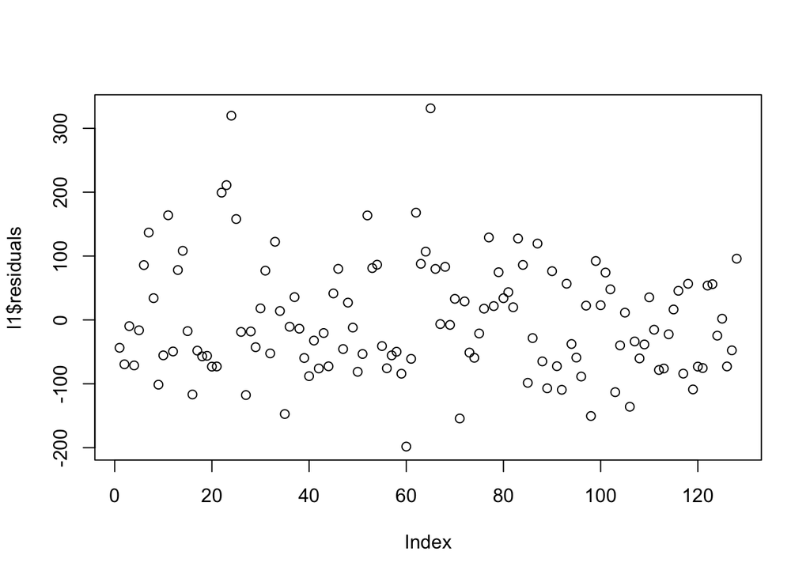

```r
#Checking if l1 fits linear regression conditions
plot(l1$residuals) #not normal
```

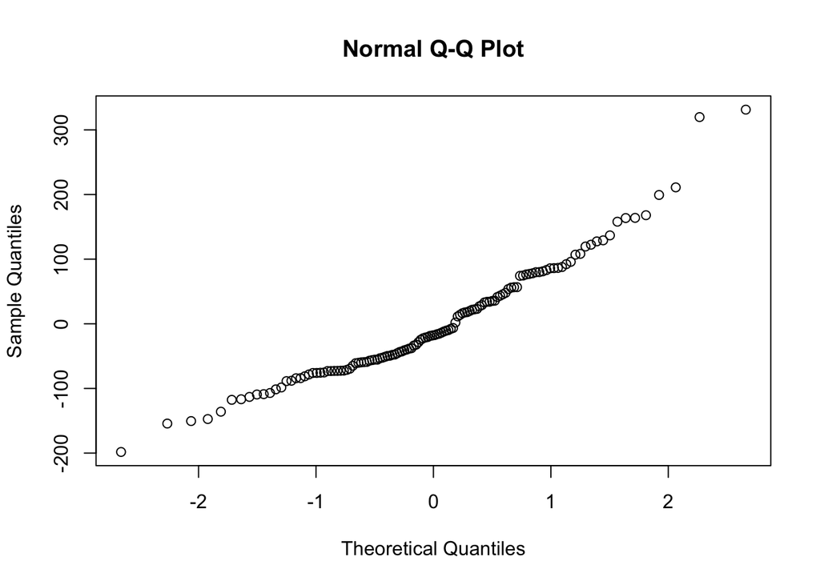

```r
qqnorm(l1$residuals) #not normal
```

```r
shapiro.test(l1$residuals) #not normal
```

```
##
##  Shapiro-Wilk normality test
##
## data:  l1$residuals
## W = 0.95167, p-value = 0.0001729
```

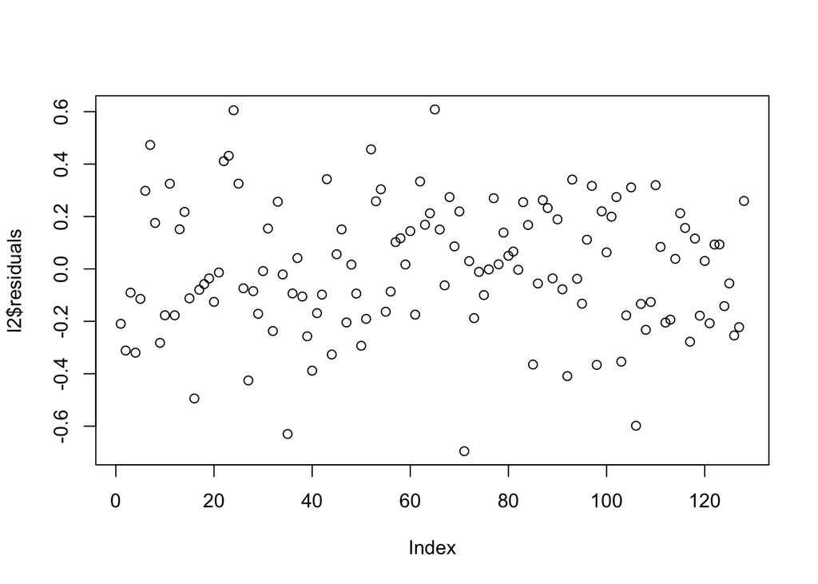

```r
#Checking if l2 fits linear regression conditions
plot(l2$residuals)
```

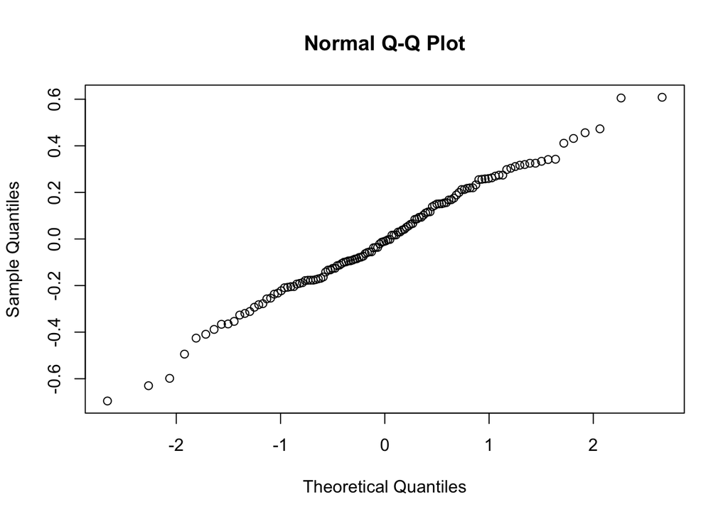

```r
qqnorm(l2$residuals)
```

```r
shapiro.test(l2$residuals)
```

```
##
##  Shapiro-Wilk normality test
##
## data:  l2$residuals
## W = 0.99261, p-value = 0.7404
```

L1 model is not normal across residual plots, qqplots & fails the shapiro.test for normality. However, the log-transformed model is normal across residual plots, qqplots & passes the shapiro.test for normality. L2 model satisfies the conditions for using linear regressions to model the relationship between brain size and longevity.

### CHALLENGE 2

#### C2, PART 1

```r
#Naming variables
log_hr <- log(d$HomeRange_km2)
log_bmf <- log(d$Body_mass_female_mean)

#runs linear regression and reports values
l3 <- lm(log_hr ~ log_bmf)
summary(l3)
```

```
##
## Call:
## lm(formula = log_hr ~ log_bmf)
##
## Residuals:
##     Min      1Q  Median      3Q     Max
## -3.3929 -0.9433 -0.0126  1.0944  3.6826
##
## Coefficients:
##             Estimate Std. Error t value Pr(>|t|)
## (Intercept) -9.44123    0.67293  -14.03   <2e-16 ***
## log_bmf      1.03643    0.08488   12.21   <2e-16 ***
## ---
## Signif. codes:  0 '***' 0.001 '**' 0.01 '*' 0.05 '.' 0.1 ' ' 1
##
## Residual standard error: 1.423 on 135 degrees of freedom
##   (76 observations deleted due to missingness)
## Multiple R-squared:  0.5248, Adjusted R-squared:  0.5213
## F-statistic: 149.1 on 1 and 135 DF,  p-value: < 2.2e-16
```

#### C2, PARTS 2, 3 & 4

```r
# bootstrap1.beta1 <- d2 %>%
#   specify(log_hr ~ log_bmf) %>%
#   generate(reps = 1000, type = "bootstrap") %>%
#   calculate(stat = "correlation")
# head(bootstrap1.beta1, 10)
#
# visualize(bootstrap1.beta1, bins = 20)

#The above only calculated for beta1, so run a loop to extract beta0 bootstrap estimate
reps <- 1000
l4.boot <- data.frame()
for (i in 1:reps){
  sample_d <- sample_n(d, size = nrow(d), replace = TRUE)
  l4 <- lm(data = sample_d, formula = log(HomeRange_km2) ~ log(Body_mass_female_mean))
  l4.coeffs <- l4$coefficients
  l4.coeffs.df <- data.frame(rep = i, intercept = l4.coeffs[1], slope = l4.coeffs[2])
  #print(l4.coeffs.df)
  l4.boot <- rbind(l4.boot, l4.coeffs.df)
  }

#Calculate SE & CI's
alpha <- 0.05
bootstrap2.summary <- l4.boot %>%
summarize(
  beta1.est = mean(slope),
  beta0.est = mean(intercept),
  se.beta0 = sd(intercept),
  se.beta1 = sd(slope),
  lower.b1 = quantile(slope, alpha/2),
  upper.b1 = quantile(slope, 1 - alpha / 2),
  lower.b0 = quantile(intercept, alpha/2),
  upper.b0 = quantile(intercept, 1 - alpha / 2))
bootstrap2.summary
```

```
##   beta1.est beta0.est  se.beta0   se.beta1  lower.b1 upper.b1  lower.b0
## 1  1.040364 -9.474191 0.6164198 0.07985313 0.8774054 1.204652 -10.75256
##    upper.b0
## 1 -8.267575
```

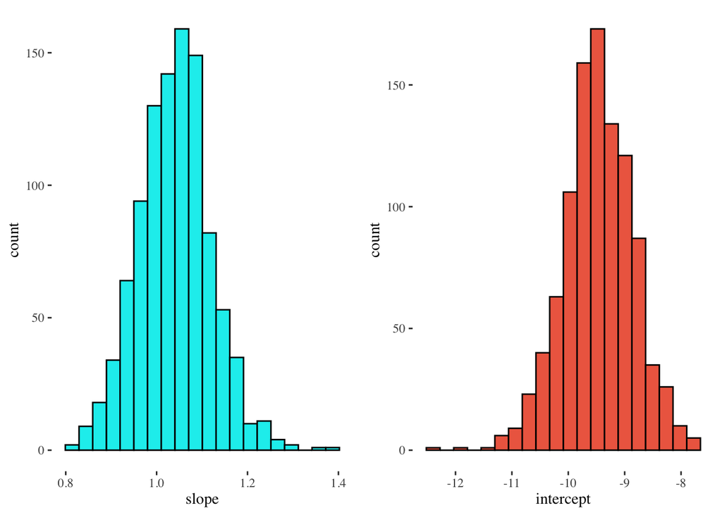

```r
#Beta0 histogram
hist2 <- ggplot(l4.boot, aes(x = intercept)) + geom_histogram(color="black", fill="coral2", bins = 20)
#Beta1 histogram
hist1 <- ggplot(l4.boot, aes(x = slope)) + geom_histogram(color="black", fill="cyan2", bins = 20)

grid.arrange(hist1, hist2, ncol = 2, nrow = 1)
```

#### C2, PART 5

```r
#tidy lm() for a clearer look
l3.tidy <- tidy(l3)
l3.tidy$std.error
```

```
## [1] 0.67293459 0.08487709
```

```r
cbind(bootstrap2.summary$se.beta0, bootstrap2.summary$se.beta1)
```

```
##           [,1]       [,2]
## [1,] 0.6164198 0.07985313
```

#### C2, PART 6

```r
#Confidence interval found in lm()
ci3 <- confint(l3, level = 0.95)
ci3
```

```
##                   2.5 %    97.5 %
## (Intercept) -10.7720889 -8.110374
## log_bmf       0.8685707  1.204292
```

```r
#beta0 CI's
cbind(bootstrap2.summary$lower.b0, bootstrap2.summary$upper.b0)
```

```
##           [,1]      [,2]
## 2.5% -10.75256 -8.267575
```

```r
#beta1 CI's
cbind(bootstrap2.summary$lower.b1, bootstrap2.summary$upper.b1)
```

```
##           [,1]     [,2]
## 2.5% 0.8774054 1.204652
```

Overall, for SE & CI’s, the bootstrap generates very close estimates as the model does.

### CHALLENGE 3

#### C3, PART 1

```r
#adding log-transformed variables to new dataframe d2
d2 <- d
d2$log_hr <-  log(d$HomeRange_km2)
d2$log_bmf <- log(d$Body_mass_female_mean)
d2$log_day <- log(d$DayLength_km)
#checking that new columns were added
colnames(d2)
```

```
##  [1] "Scientific_Name"         "Family"
##  [3] "Genus"                   "Species"
##  [5] "Brain_Size_Species_Mean" "Brain_Size_Female_Mean"
##  [7] "Brain_size_Ref"          "Body_mass_male_mean"
##  [9] "Body_mass_female_mean"   "Mass_Dimorphism"
## [11] "Mass_Ref"                "MeanGroupSize"
## [13] "AdultMales"              "AdultFemale"
## [15] "AdultSexRatio"           "Social_Organization_Ref"
## [17] "InterbirthInterval_d"    "Gestation"
## [19] "WeaningAge_d"            "MaxLongevity_m"
## [21] "LitterSz"                "Life_History_Ref"
## [23] "GR_MidRangeLat_dd"       "Precip_Mean_mm"
## [25] "Temp_Mean_degC"          "AET_Mean_mm"
## [27] "PET_Mean_mm"             "Climate_Ref"
## [29] "HomeRange_km2"           "HomeRangeRef"
## [31] "DayLength_km"            "DayLengthRef"
## [33] "Territoriality"          "Fruit"
## [35] "Leaves"                  "Fauna"
## [37] "DietRef1"                "Canine_Dimorphism"
## [39] "Canine_Dimorphism_Ref"   "Feed"
## [41] "Move"                    "Rest"
## [43] "Social"                  "Activity_Budget_Ref"
## [45] "log_hr"                  "log_bmf"
## [47] "log_day"
```

```r
#Creating Function
boot_lm <- function(d, model, conf.level = 0.95, reps = 1000){
  l5 <- lm(data = d2, formula = model)
  l5.CI <- confint(l5, level = conf.level)
  l5.tidy <-tidy(l5)
  l5.coeffs <- l5.tidy$estimate
  l5.sd <- l5.tidy$std.error
  l5.info <- data.frame(l5.coeffs, l5.sd, l5.CI)
  names(l5.info) <- c("lm.est", "lm.sd", "lm.CI.lower", "lm.CI.upper")
  bootresults <- data.frame()
  for (i in 1:reps){
  sample_d2 <- sample_n(d2, size = nrow(d2), replace = TRUE)
  l6 <- lm(data = sample_d2, formula = model)
  l6.tidy <-tidy(l6)
  l6.coeffs <- l6.tidy$estimate
  bootresults <- rbind(bootresults, l6.coeffs)
  }
  mean <- summarize_all(
    bootresults, .funs = mean
  )
  names(mean) <- l5.tidy$term
  sd <- summarize_all(
    bootresults, .funs = sd
  )
  names(sd) <- l5.tidy$term
  upper <- summarize_all(
    bootresults, .funs = quantile, 1-(1-conf.level)/2
  )
  names(upper) <- l5.tidy$term
  lower <- summarize_all(
    bootresults, .funs = quantile, (1-conf.level)/2
  )
  names(lower) <- l5.tidy$term
  #combining all & transposing
  results <- as.data.frame(t(bind_rows(mean, sd, lower, upper)))
  names(results) <- c("boot.est", "boot.sd", "boot.CI.lower", "boot.CI.upper")
  results <- bind_cols(l5.info, results)
  rownames(results) <- l5.tidy$term
  return(results)
}

#log(HomeRange_km2) ~ log(Body_mass_female_mean)
model <- "log_hr ~ log_bmf"
boot_lm(d,model)
```

```
##                lm.est      lm.sd lm.CI.lower lm.CI.upper  boot.est    boot.sd
## (Intercept) -9.441231 0.67293459 -10.7720889   -8.110374 -9.458386 0.59499592
## log_bmf      1.036432 0.08487709   0.8685707    1.204292  1.038958 0.07611471
##             boot.CI.lower boot.CI.upper
## (Intercept)   -10.6377658     -8.357030
## log_bmf         0.9008876      1.188587
```

```r
#check to see if l4 was replicated in function
tidy(l4)
```

```
## # A tibble: 2 x 5
##   term                       estimate std.error statistic  p.value
##   <chr>                         <dbl>     <dbl>     <dbl>    <dbl>
## 1 (Intercept)                  -8.78     0.604      -14.5 9.42e-30
## 2 log(Body_mass_female_mean)    0.946    0.0777      12.2 1.03e-23
```

```r
#log(DayLength_km) ~ log(Body_mass_female_mean)
model <- "log_day ~ log_bmf"
boot_lm(d,model)
```

```
##                 lm.est     lm.sd lm.CI.lower lm.CI.upper    boot.est    boot.sd
## (Intercept) -0.1427624 0.4650068 -1.06510122   0.7795764 -0.14097309 0.45128522
## log_bmf      0.0389422 0.0566739 -0.07347022   0.1513546  0.03862504 0.05731161
##             boot.CI.lower boot.CI.upper
## (Intercept)   -1.08756591     0.7174561
## log_bmf       -0.07159018     0.1573413
```

```r
#check
l6 <- lm(data = d2, log_hr ~ log_bmf + MeanGroupSize)
summary(l6)
```

```
##
## Call:
## lm(formula = log_hr ~ log_bmf + MeanGroupSize, data = d2)
##
## Residuals:
##     Min      1Q  Median      3Q     Max
## -3.2688 -0.8016  0.1044  1.0073  3.3151
##
## Coefficients:
##                Estimate Std. Error t value Pr(>|t|)
## (Intercept)   -8.656777   0.697528 -12.411  < 2e-16 ***
## log_bmf        0.849707   0.094212   9.019 5.32e-15 ***
## MeanGroupSize  0.043348   0.007887   5.496 2.40e-07 ***
## ---
## Signif. codes:  0 '***' 0.001 '**' 0.01 '*' 0.05 '.' 0.1 ' ' 1
##
## Residual standard error: 1.279 on 114 degrees of freedom
##   (96 observations deleted due to missingness)
## Multiple R-squared:  0.6318, Adjusted R-squared:  0.6253
## F-statistic: 97.81 on 2 and 114 DF,  p-value: < 2.2e-16
```

```r
#log(HomeRange_km2) ~ log(Body_mass_female_mean) + MeanGroupSize
model <- "log_hr ~ log_bmf + MeanGroupSize"
boot_lm(d,model)
```

```
##                   lm.est       lm.sd  lm.CI.lower lm.CI.upper    boot.est
## (Intercept)   -8.6567772 0.697528179 -10.03857515 -7.27497925 -8.66793171
## log_bmf        0.8497067 0.094212231   0.66307301  1.03634042  0.85064063
## MeanGroupSize  0.0433480 0.007886999   0.02772391  0.05897208  0.04379827
##                   boot.sd boot.CI.lower boot.CI.upper
## (Intercept)   0.606846513    -9.8753257   -7.41191993
## log_bmf       0.080280148     0.6862845    1.00987761
## MeanGroupSize 0.007213642     0.0302617    0.06041367
```

```r
#check
l7 <- lm(data = d2, log_hr ~ log_bmf + MeanGroupSize)
summary(l7)
```

```
##
## Call:
## lm(formula = log_hr ~ log_bmf + MeanGroupSize, data = d2)
##
## Residuals:
##     Min      1Q  Median      3Q     Max
## -3.2688 -0.8016  0.1044  1.0073  3.3151
##
## Coefficients:
##                Estimate Std. Error t value Pr(>|t|)
## (Intercept)   -8.656777   0.697528 -12.411  < 2e-16 ***
## log_bmf        0.849707   0.094212   9.019 5.32e-15 ***
## MeanGroupSize  0.043348   0.007887   5.496 2.40e-07 ***
## ---
## Signif. codes:  0 '***' 0.001 '**' 0.01 '*' 0.05 '.' 0.1 ' ' 1
##
## Residual standard error: 1.279 on 114 degrees of freedom
##   (96 observations deleted due to missingness)
## Multiple R-squared:  0.6318, Adjusted R-squared:  0.6253
## F-statistic: 97.81 on 2 and 114 DF,  p-value: < 2.2e-16
```

### Extra Credit

sometimes it’s OK to throw in the towel…

```r
#set model
model <- "log_hr ~ log_bmf"
for (i in seq(from = 10, to = 200, by = 10)){
  bootstrap4 <- boot_lm(d, model, reps = i)
  y.line <- as.data.frame(t(bootstrap4$boot.est))
  #ext.p <- ggplot(data = bootstrap4, aes(x = i, y = y.line$V2)) +
    #geom_point() + #check to see if it's plotting at all
    #geom_smooth(method = lm) #plot as lines
}
```